# KGP_Kern slides

## Machine Learning for Engineering

## Kernels and Gaussian Processes: Kernel method

### Instructor: Daning Huang

## TODAY: Kernels and GP - I

- Kernel functions
- Kernel trick
- Kernel ridge regression

### References

- [MLaPP] Chp. 14.2, 14.4
- [PRML] Chp. 6

## Rethinking Linear Regression

**Problem:** Vanilla linear model $y(x) = w^T x$ can only produce straight lines/hyperplanes through the origin.

- Not very flexible / powerful
- Cannot handle nonlinearities

**Solution:** Regression with some features

- e.g., replace $x$ by $\phi(x) = [1, x, x^2, \cdots, x^p]^T$
- The feature mapping $\phi$ is nonlinear
- But in feature space the problem becomes linear!

### Feature Mapping (or Lifting, Embedding, etc.)

Our models so far employ a nonlinear **feature mapping** $\phi : \mathcal{X} \mapsto \mathbb{R}^M$

- in general, features are nonlinear functions of the data
- each feature $\phi_j(x)$ extracts important properties from $x$

Ultimately, this allows us to use **linear** methods for **nonlinear** tasks.

### Example

**Problem:** Find a linear perspective for the following scattered data.

- Left: Already linear in the current coordinates
- Right: Nonlinear - how to transform the coordinates (or, find the right features)

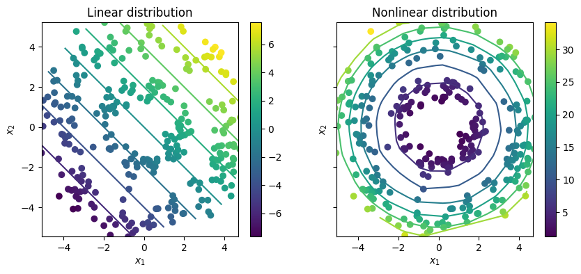

```python
plot_circular_data(100)
```

#### Solution 1

Add squared-distance-to-origin $\phi(x)=(x_1^2 + x_2^2)$ as third feature.

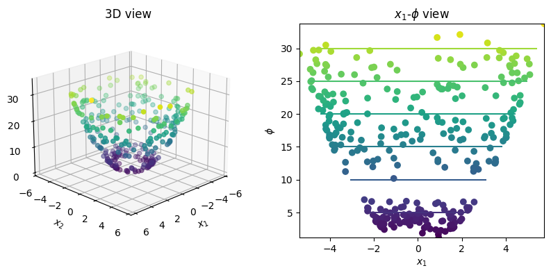

```python
plot_circular_3d(100)
```

#### Solution 2

Replace $(x_1, x_2)$ with $(\phi_1,\phi_2) = (x_1^2, x_2^2)$

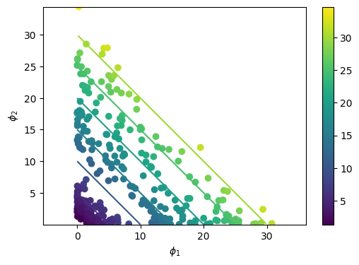

```python
plot_circular_squared(100)
```

### What feature mapping does

Data has been mapped via $\phi$ to a new, higher-dimensional space

- Certain *representations* are better for certain problems

Alternatively, the data still lives in original space, but the definition of **distance** or **inner product** has changed.

- Certain *inner products* are better for certain problems

> More on the second bullet soon.

#### Effective, but...

How do I choose a feature mapping $\phi(x)$?

- Manually? Learn features?

With $N$ examples and $M$ features,

- design matrix is $\Phi \in \mathbb{R}^{N \times M}$
- linear regression requires inverting $\Phi^T \Phi \in \mathbb{R}^{M \times M}$
- computational complexity of $O(M^3)$ - too high if too many features?
- If many features, we need many more data, so that $N\gg M$ - not always possible!

**In other words**, higher-dimensional features come at a price:

- We cannot manage high/infinite-dimensional $\phi(x)$.
- Computational complexity blows up.

Kernel methods to the rescue!

## Kernel Functions

Many algorithms depend on the data only through pairwise **inner products** between data points, $$ \langle x_1, x_2 \rangle = x_2^T x_1 $$

Inner products can be replaced by **Kernel Functions**, capturing more general notions of *similarity*.

- No longer need coordinates!

### Definition

A **kernel function** $\kappa(x,x’)$ is intended to measure the similarity between $x$ and $x’$.

- So far, we have used the standard inner product in the **transformed space**, $$ \kappa(x, x') = \phi(x)^T \phi(x') $$
- In general, $\kappa(x, x')$ is any symmetric positive-semidefinite function. This means that for every set $x_1, ..., x_n$, the matrix $[\kappa(x_i,x_j)]_{i,j\in[n]}$ is a PSD matrix.

#### Kernels as implicit feature map

For every valid kernel function $\kappa(x, x')$,

- there is an implicit feature mapping $\phi(x)$
- corresponding to an inner product $\phi(x)^T \phi(x')$ in some high-dimensional feature space
- And sometimes infinite dimensional!

This *incredible* result follows from **Mercer's Theorem**,

- Generalizes the fact that *every positive-definite matrix corresponds to an inner product*
- For more info, see [Reproducing Kernel Hilbert Space (RKHS)](https://en.wikipedia.org/wiki/Reproducing_kernel_Hilbert_space), and later in lecture.

### Some Examples

**Kernel:** For $x = (x_1, x_2)$ and $z=(z_1, z_2)$, define $$ \begin{align*} \kappa(x, z) &= (x^Tz)^2 \\ &= (x_1z_1 + x_2z_2)^2 \\ &= x_1^2z_1^2 + 2x_1z_1x_2z_2 + x_2^2z_2^2 \end{align*} $$

**Mapping:** Equivalent to the standard inner product when either $$ \begin{gather*} \phi(x) = (x_1^2, \sqrt{2} x_1 x_2, x_2^2) \\ \phi(x) = (x_1^2, x_1 x_2, x_1 x_2, x_2^2) \end{gather*} $$

> Implicit mapping is **not** unique, but a standard choice would be given by [Mercer's theorem](https://en.wikipedia.org/wiki/Reproducing_kernel_Hilbert_space#Integral_operators_and_Mercer%27s_theorem).

#### Mononomials

**Kernel:** Higher-order mononomial of degree $p$, $$ \kappa(x,z) = (x^T z)^p = \left( \sum_{k=1}^M x_k z_k \right)^p $$

**Mapping:** Implicit feature vector $\phi(x)$ contains all monomials of degree $p$

#### Polynomials

**Kernel:** Inhomogeneous polynomial up to degree $p$, for $c > 0$, $$ \kappa(x,z) = (x^T z + c)^p = \left(c + \sum_{k=1}^M x_k z_k \right)^p $$

**Mapping:** Implicit feature vector $\phi(x)$ contains all monomials of degree $\leq p$

#### Applying to CFD solutions

Take the pixel values and compute $\kappa(x,z) = (x^Tz + 1)^p $

- here, $x$ = $449 \times 129 \approx 60k$ nodes, (From NASA Langley)

[figure not shown]

You can compute the inner product in the space of all monomials up to degree $p$

- For $dim(x)\approx 60k$ and $p=3$ a $32T$ dimensional space!

## Constructing Kernels

#### Method 1

Explicitly define a feature space mapping $\phi(x)$ and use **inner product kernel** $$ \kappa(x,x') = \phi(x)^T \phi(x') = \sum_{i=1}^{M}\phi_i(x) \phi_i(x') $$

#### Method 2

Explicitly define a kernel $\kappa(x,x')$ and identify the implicit feature map, e.g. $$ \kappa(x,z) = (x^Tz)^2 \quad \implies \quad \phi(x) = (x_1^2, \sqrt{2} x_1 x_2, x_2^2) $$

> Kernels help us avoid the complexity of explicit feature mappings.

#### Method 3

Define a similarity function $\kappa(x, x')$ and use **Mercer's Condition** to verify that an implicit feature map *exists* without finding it.

- Define the Gram matrix $K$ to have elements $K_{nm} = \kappa(x_n,x_m)$
- $K$ must **positive semidefinite** for all possible choices of the data set {$x_n$} $$ a^TKa \equiv \sum_{i}\sum_{j} a_i K_{ij} a_j \geq 0 \quad \forall\, a \in \mathbb{R}^n $$

### Building Blocks

There are a number of axioms that help us construct new, more complex kernels, from simpler known kernels.

- For kernels $\kappa_1$ and $\kappa_2$, and a positive scalar $s$, then the following are kernels too:

$$ \kappa_1+\kappa_2,\quad s\kappa_1,\quad \kappa_1\kappa_2 $$

> You will prove some specific cases in homework
- For example, the following are kernels: $$ \begin{align*} \kappa(x, x') &= f(x) \kappa_1(x,x') f(x') \\ \kappa(x, x') &= \exp( \kappa_1(x, x') ) \end{align*} $$

### Popular Kernel Functions

- Simple Polynomial Kernel (terms of degree $2$) $$\kappa(x,z) = (x^Tz)^2 $$
- Generalized Polynomial Kernel (degree $M$) $$\kappa(x,z) = (x^Tz + c)^M, c > 0 $$
- Gaussian Kernels $$ \kappa(x,z) = \exp \left\{-\frac{\|x-z\|^2}{2\sigma^2} \right\} $$

#### Particularly for Gaussian Kernel

> **Not related to Gaussian PDF!**
- Translation invariant (depends only on distance between points)
- Corresponds to an infinitely dimensional space!

## The Kernel Trick

What kernels essentially do

- Compute inner products in a high dimensional space (i.e., $\phi$).
- But with only the computational cost of a low dimensional space (i.e., $x$).

What kernel trick does

- Many algorithms can be expressed completely in kernels/inner products $\kappa(x,x’)$, rather than other operations on $x$, e.g., $\phi(x)$.
- Huge reduction in cost ($x$ instead of $\phi$), but still with high expressibility ($\phi$).

### Example: Similarity

Conventionally the similarity between two points $x$ and $z$ can be quantified as the "angle" between vectors $$ s(x,z) = \frac{x^T z}{\|x\|\|z\|} $$

In feature space, we can generalize as $$ s(x,z) = \frac{\phi(x)^T \phi(z)}{\|\phi(x)\|\|\phi(z)\|} $$

But this is simply $$ s(x,z) = \frac{k(x,z)}{\sqrt{k(x,x)k(z,z)}} $$

### Example: Distance

Distance between samples can be expressed in inner products: $$ \begin{align*} \|\phi(x) - \phi(z) \|^2 &= \langle\phi(x)- \phi(z), \phi(x)- \phi(z) \rangle\\ &= \langle \phi(x), \phi(x)\rangle - 2\langle\phi(x), \phi(z)\rangle + \langle\phi(z), \phi(z) \rangle \\ &= \kappa(x,x) - 2\kappa(x,z) + \kappa(z,z) \end{align*} $$

### Example: Distance to the Mean

- Mean of data points given by: $\phi(s) = \frac{1}{N}\sum_{i=1}^{N}\phi(x_i)$
- Distance to the mean: $$ \begin{align*} \|\phi(x) - \phi_s \|^2 &= \langle\phi(x)- \phi_s, \phi(x)- \phi_s \rangle\\ &= \langle \phi(x), \phi(x)\rangle - 2\langle\phi(x), \phi_s\rangle + \langle\phi_s, \phi_s \rangle \\ &= \kappa(x,x) - \frac{2}{N}\sum_{i=1}^{N}\kappa(x,x_i) + \frac{1}{N^2}\sum_{j=1}^{N}\sum_{i=1}^{N}\kappa(x_i,x_j) \end{align*} $$

### Example: Ridge Regression

This is the main goal for this lecture, see next ...

## Kernelizing the Ridge Regression

### Recall ...

- Linear Regression Model $$ y(x,w) = w^T \phi (x) = \sum_{j=0}^{M} w_j \phi_j(x) $$
- Ridge Regression $$ J(w) = \frac{1}{2} \sum_{n=1}^{N}(w^T \phi (x_n) - t_n)^2 + \frac{\lambda}{2}w^Tw $$
- Closed-form Solution $$ w = (\Phi^T \Phi + \lambda I)^{-1}\Phi^T t $$

### Dualization

We want to minimize: $J(w) = \frac{1}{2} \sum_{n=1}^{N}(w^T \phi (x_n) - t_n)^2 + \frac{\lambda}{2}w^Tw$

Taking $\nabla J(w) = 0$, we obtain: $$ \begin{align*} w &= -\frac{1}{\lambda}\sum_{n=1}^{N}(w^T\phi(x_n) - t_n) \phi(x_n) \\ &\equiv \sum_{n=1}^{N}a_n\phi(x_n) = \Phi^Ta \end{align*} $$ Notice: $w$ can be written as a linear combination of $\phi(x_n)$!

Transform $J(w)$ to $J(a)$ by substituting $ w = \Phi^T a$

- Where $a_n = -\frac{1}{\lambda}\left(w^T\phi(x_n) - t_n\right)$
- Let $a = (a_1, \dots, a_N)^T$ be the parameter, instead of $w$.

### Dual Representation

Substituting $w = \Phi^Ta$, $$ \begin{align*} J(a) &= \frac12 w^T \Phi^T \Phi w - w^T \Phi^T t + \frac12 t^T t + \frac{\lambda}{2} w^T w \\ &= \frac{1}{2} (a^T\Phi) \Phi^T \Phi (\Phi^Ta) - (a^T\Phi) \Phi^Tt + \frac{1}{2}t^Tt + \frac{\lambda}{2}(a^T\Phi)(\Phi^Ta) \\ &= \frac{1}{2} a^T {\color{red}{(\Phi \Phi^T) (\Phi \Phi^T)}} a - a^T {\color{red}{(\Phi\Phi^T)}} t + \frac{1}{2}t^Tt + \frac{\lambda}{2}a^T {\color{red}{(\Phi\Phi^T)}} a \\ &= \frac{1}{2}a^TKKa - a^T Kt + \frac{1}{2}t^Tt + \frac{\lambda}{2}a^TKa \end{align*} $$

More concisely, $$ J(a) = \|Ka-t\|_2^2 + \lambda \|a\|_K^2 $$

- The first term is the usual prediction error
- The second term is a "K-norm", which is technically the RKHS norm - it controls smoothness.
- The solution is

$$ {a = (K+\lambda I_N)^{-1}t} $$

The predictive model becomes $$ y(x) = w^T\phi(x) = a^T \Phi\phi(x) = a^T k(x) $$ where $$ k(x) = \Phi \phi(x) = [\kappa(x_1,x), \kappa(x_2,x), \ldots, \kappa(x_N,x)]^T $$

- We have gotten rid of all $\phi$!

### Comparison

**Primal** - Ridge Regression: $w = (\Phi^T\Phi + \lambda I_M)^{-1} \Phi^Tt $

- invert $\Phi^T \Phi \in \mathbb{R}^{M \times M}$
- cheaper since usually $N \gg M$
- must explicitly construct features

**Dual** - Kernel Ridge Regression: $ a = (K + \lambda I_N)^{-1}t $

- invert Gram matrix $K \in \mathbb{R}^{N \times N}$
- use kernel trick to avoid feature construction
- use kernels $\kappa(x, x')$ to represent similarity over vectors, images, sequences, graphs, text, etc..

### Kernel Ridge Regression: Example

#### Baseline

"rbf": $\kappa(x,y)=\exp(-\gamma\|x-y\|^2)$

Linear data plus noise.

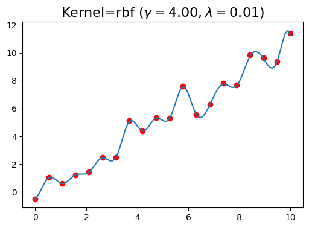

```python
# Tries to match everything, but no severe overfitting
plot_kernel_ridge(X, y, gamma=4, lmbd=0.01, ker='rbf')
```

#### Larger penalty

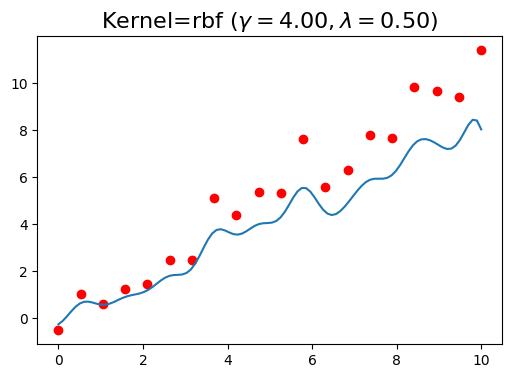

```python
# Smoother and less variation
plot_kernel_ridge(X, y, gamma=4, lmbd=0.5, ker='rbf')
```

#### Smaller bandwidth

$\kappa(x,y)=\exp(-\gamma\|x-y\|^2)$

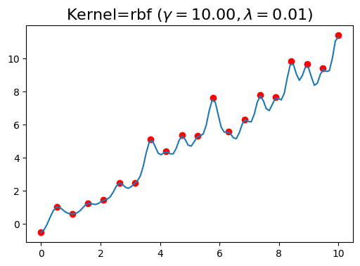

```python
# More localized
plot_kernel_ridge(X, y, gamma=10, lmbd=0.01)
```

#### Changing kernel

"linear": $\kappa(x,y)=x^Ty$

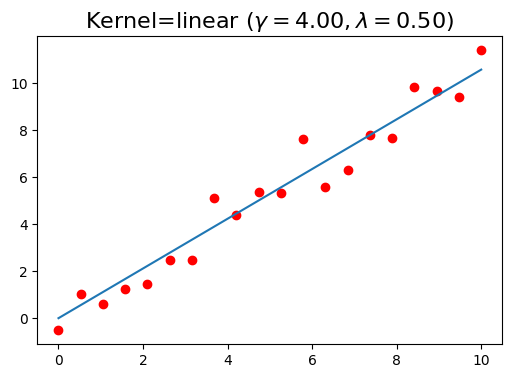

```python
# Effectively a regularized linear fit
plot_kernel_ridge(X, y, gamma=4, lmbd=0.5, ker='linear')
```

### Two More Perspectives

#### Kernel itself as features

For a dataset $\{x_i\}_{i=1}^N$, pick a kernel $\kappa$ and define features as $$ \tilde{\phi}_i(x) = \kappa(x,x_i) $$ i.e., each sample corresponds to one feature.

The KRR model is $$ y(x) = \sum_{i=1}^N a_i\kappa(x,x_i) \equiv \tilde{\phi}(x)^T a $$

So we could have treated KRR as a regular ridge regression.

- In fitting, $\tilde{\phi}_i$ forms a $\Phi$ that is exactly $K$.
- The difference: the regularization in KRR $\|a\|_K^2$ but RR would use $\|a\|_2^2$.

This view has a deep connection to the Reproducing Kernel Hilbert Space (RKHS).

- The collection $\{f(x) \mid f(x)=\sum_{i=1}^N a_i\kappa(x,x_i),\, a_i\in\mathbb{R}\}$ is a function space
- Upon "completion", the space becomes RKHS
- The many nice properties of RKHS guarantee the nice properties of KRR

> See the theoretical slides for more details.

#### Bias-variance trade-off

Recall from Ridge Regression with $m$ features and $n$ data points, we had $$ \mathbb{E}[(y - \hat{f})^2] = \underbrace{O({\sigma^2})}_\text{irreducible error} + \underbrace{O(\sigma^2\frac{{\tilde{m}}}{n})}_\text{Variance} + \underbrace{O({\tilde{m}}^{-p})}_{\text{Bias}^2} $$ where the **effective** number of features were introduced $$ {\tilde{m}} = \sum_{j=1}^m \frac{\nu_i}{\nu_i+\lambda} $$ and $\nu_i$'s are the eigenvalues of $\Phi^\top\Phi$.

- For $d$-dimensional input $x$ and $p$th-order polynomial features: $m\sim d^p$
- $m$ explodes for even moderate $d$ and $p$.
- **Huge** variance would be introduced.

Now in Kernel version, we effectively have $m=n$ features instead

- so $\nu_i$'s are the eigenvalues of $K$.
- and $$ \text{Variance}\sim \frac{\tilde{m}}{n} < 1\quad\rightarrow\text{Under control!} $$

## Side Note: Locally-Weighted Linear Regression

LWLR is also frequently used. It "looks like" but is **not** KRR.

**Main Idea:** When predicting $f(x)$, give high weights for *neighbors* of $x$.

[figure not shown]

### Regular vs. Locally-Weighted Linear Regression

[figure not shown]

**Linear Regression**

1. Fit $w$ to minimize $\sum_{k} (t_k - w^T \phi(x_k) )^2$  
2. Output $w^T \phi(x_k)$

**Locally-weighted Linear Regression**

1. Fit $w$ to minimize $\sum_{k} r_k (t_k - w^T \phi(x_k) )^2$ for some weights $r_k$  
2. Output $w^T \phi(x_k)$

- The standard choice for weights $r$ uses the **Gaussian Kernel**, with **kernel width** $\tau$ $$ r_k = \exp\left( -\frac{|| x_k - x ||^2}{2\tau^2} \right) $$
- Note $r_k$ depends on both $x$ (query point); must **solve linear regression for each query point $x$**.
- Can be reformulated as a modified version of least squares problem.
- Choice of kernel width matters.
  - (requires hyperparameter tuning!)

[figure not shown]

> The estimator is minimized when kernel includes as many training points as can be accomodated by the model. Too large a kernel includes points that degrade the fit; too small a kernel neglects points that increase confidence in the fit.

### KRR v.s. LWLR: Similarities

Both methods are “instance-based learning”, i.e., non-parametric method

- Only observations (training set) close to the query point are considered (highly weighted) for regression computation.
- Kernel determines how to assign weights to training examples (similarity to the query point x)
- Free to choose types of kernels
- Both can suffer when the dataset size is large.

### KRR v.s. LWLR: Differences

- *LWLR:* Weighted regression; slow, but more accurate
- *KRR:* Weighted mean; faster, but less accurate